# Risk Factor Analysis

## Outcome Variable

**Outcome Variable:** swasted

## Predictor Variables

**Intervention Variable:** vagbrth

**Adjustment Set:**

unadjusted

## Stratifying Variables

The analysis was stratified on these variable(s):

- agecat
- studyid
- country

## Data Summary

| agecat | studyid | country | vagbrth | swasted | n_cell | n |
| --- | --- | --- | --- | --- | --- | --- |
| Birth | ki1000108-CMC-V-BCS-2002 | INDIA | 0 | 0 | 10 | 88 |
| Birth | ki1000108-CMC-V-BCS-2002 | INDIA | 0 | 1 | 0 | 88 |
| Birth | ki1000108-CMC-V-BCS-2002 | INDIA | 1 | 0 | 73 | 88 |
| Birth | ki1000108-CMC-V-BCS-2002 | INDIA | 1 | 1 | 5 | 88 |
| Birth | ki1000108-IRC | INDIA | 0 | 0 | 52 | 343 |
| Birth | ki1000108-IRC | INDIA | 0 | 1 | 14 | 343 |
| Birth | ki1000108-IRC | INDIA | 1 | 0 | 237 | 343 |
| Birth | ki1000108-IRC | INDIA | 1 | 1 | 40 | 343 |
| Birth | ki1017093c-NIH-Crypto | BANGLADESH | 0 | 0 | 1 | 17 |
| Birth | ki1017093c-NIH-Crypto | BANGLADESH | 0 | 1 | 0 | 17 |
| Birth | ki1017093c-NIH-Crypto | BANGLADESH | 1 | 0 | 15 | 17 |
| Birth | ki1017093c-NIH-Crypto | BANGLADESH | 1 | 1 | 1 | 17 |
| Birth | ki1119695-PROBIT | BELARUS | 0 | 0 | 1501 | 13824 |
| Birth | ki1119695-PROBIT | BELARUS | 0 | 1 | 92 | 13824 |
| Birth | ki1119695-PROBIT | BELARUS | 1 | 0 | 11412 | 13824 |
| Birth | ki1119695-PROBIT | BELARUS | 1 | 1 | 819 | 13824 |
| Birth | ki1126311-ZVITAMBO | ZIMBABWE | 0 | 0 | 1016 | 12813 |
| Birth | ki1126311-ZVITAMBO | ZIMBABWE | 0 | 1 | 83 | 12813 |
| Birth | ki1126311-ZVITAMBO | ZIMBABWE | 1 | 0 | 11011 | 12813 |
| Birth | ki1126311-ZVITAMBO | ZIMBABWE | 1 | 1 | 703 | 12813 |
| Birth | kiGH5241-JiVitA-3 | BANGLADESH | 0 | 0 | 2 | 15689 |
| Birth | kiGH5241-JiVitA-3 | BANGLADESH | 0 | 1 | 0 | 15689 |
| Birth | kiGH5241-JiVitA-3 | BANGLADESH | 1 | 0 | 15434 | 15689 |
| Birth | kiGH5241-JiVitA-3 | BANGLADESH | 1 | 1 | 253 | 15689 |
| Birth | kiGH5241-JiVitA-4 | BANGLADESH | 0 | 0 | 1 | 683 |
| Birth | kiGH5241-JiVitA-4 | BANGLADESH | 0 | 1 | 0 | 683 |
| Birth | kiGH5241-JiVitA-4 | BANGLADESH | 1 | 0 | 677 | 683 |
| Birth | kiGH5241-JiVitA-4 | BANGLADESH | 1 | 1 | 5 | 683 |
| 6 months | ki1000108-CMC-V-BCS-2002 | INDIA | 0 | 0 | 25 | 368 |
| 6 months | ki1000108-CMC-V-BCS-2002 | INDIA | 0 | 1 | 0 | 368 |

[output cut: 70 more lines]

The following strata were considered:

- agecat: 24 months, studyid: ki1000108-CMC-V-BCS-2002, country: INDIA
- agecat: 24 months, studyid: ki1000108-IRC, country: INDIA
- agecat: 24 months, studyid: ki1017093b-PROVIDE, country: BANGLADESH
- agecat: 24 months, studyid: ki1017093c-NIH-Crypto, country: BANGLADESH
- agecat: 24 months, studyid: ki1066203-TanzaniaChild2, country: TANZANIA, UNITED REPUBLIC OF
- agecat: 24 months, studyid: ki1119695-PROBIT, country: BELARUS
- agecat: 24 months, studyid: ki1126311-ZVITAMBO, country: ZIMBABWE
- agecat: 24 months, studyid: kiGH5241-JiVitA-3, country: BANGLADESH
- agecat: 24 months, studyid: kiGH5241-JiVitA-4, country: BANGLADESH
- agecat: 6 months, studyid: ki1000108-CMC-V-BCS-2002, country: INDIA
- agecat: 6 months, studyid: ki1000108-IRC, country: INDIA
- agecat: 6 months, studyid: ki1017093b-PROVIDE, country: BANGLADESH
- agecat: 6 months, studyid: ki1017093c-NIH-Crypto, country: BANGLADESH
- agecat: 6 months, studyid: ki1066203-TanzaniaChild2, country: TANZANIA, UNITED REPUBLIC OF
- agecat: 6 months, studyid: ki1119695-PROBIT, country: BELARUS
- agecat: 6 months, studyid: ki1126311-ZVITAMBO, country: ZIMBABWE
- agecat: 6 months, studyid: kiGH5241-JiVitA-3, country: BANGLADESH
- agecat: 6 months, studyid: kiGH5241-JiVitA-4, country: BANGLADESH
- agecat: Birth, studyid: ki1000108-CMC-V-BCS-2002, country: INDIA
- agecat: Birth, studyid: ki1000108-IRC, country: INDIA
- agecat: Birth, studyid: ki1017093c-NIH-Crypto, country: BANGLADESH
- agecat: Birth, studyid: ki1119695-PROBIT, country: BELARUS
- agecat: Birth, studyid: ki1126311-ZVITAMBO, country: ZIMBABWE
- agecat: Birth, studyid: kiGH5241-JiVitA-3, country: BANGLADESH
- agecat: Birth, studyid: kiGH5241-JiVitA-4, country: BANGLADESH

### Dropped Strata

Some strata were dropped due to rare outcomes:

- agecat: Birth, studyid: ki1000108-CMC-V-BCS-2002, country: INDIA
- agecat: Birth, studyid: ki1017093c-NIH-Crypto, country: BANGLADESH
- agecat: Birth, studyid: kiGH5241-JiVitA-3, country: BANGLADESH
- agecat: Birth, studyid: kiGH5241-JiVitA-4, country: BANGLADESH
- agecat: 6 months, studyid: ki1000108-CMC-V-BCS-2002, country: INDIA
- agecat: 6 months, studyid: ki1000108-IRC, country: INDIA
- agecat: 6 months, studyid: ki1017093b-PROVIDE, country: BANGLADESH
- agecat: 6 months, studyid: ki1017093c-NIH-Crypto, country: BANGLADESH
- agecat: 6 months, studyid: ki1066203-TanzaniaChild2, country: TANZANIA, UNITED REPUBLIC OF
- agecat: 6 months, studyid: ki1119695-PROBIT, country: BELARUS
- agecat: 6 months, studyid: kiGH5241-JiVitA-4, country: BANGLADESH
- agecat: 24 months, studyid: ki1000108-CMC-V-BCS-2002, country: INDIA
- agecat: 24 months, studyid: ki1000108-IRC, country: INDIA
- agecat: 24 months, studyid: ki1017093b-PROVIDE, country: BANGLADESH
- agecat: 24 months, studyid: ki1017093c-NIH-Crypto, country: BANGLADESH
- agecat: 24 months, studyid: ki1066203-TanzaniaChild2, country: TANZANIA, UNITED REPUBLIC OF
- agecat: 24 months, studyid: ki1119695-PROBIT, country: BELARUS
- agecat: 24 months, studyid: ki1126311-ZVITAMBO, country: ZIMBABWE

## Methods Detail

We’re interested in the causal parameters $E[Y_a]$ for all values of $a \in \mathcal{A}$. These parameters represent the mean outcome if, possibly contrary to fact, we intervened to set all units to have $A=a$. Under the randomization and positivity assumptions, these are identified by the statistical parameters $\psi_a=E_W[E_{Y|A,W}(Y|A=a,W)]$. In addition, we’re interested in the mean of $Y$, $E[Y]$ under no intervention (the observed mean). We will estimate these parameters by using SuperLearner to fit the relevant likelihood factors – $E_{Y|A,W}(Y|A=a,W)$ and $p(A=a|W)$, and then updating our likelihood fit using a joint TMLE.

For unadjusted analyses ($W=\{\}$), initial likelihoods were estimated using Lrnr_glm to estimate the simple $E(Y|A)$ and Lrnr_mean to estimate $p(A)$. For adjusted analyses, a small library containing Lrnr_glmnet, Lrnr_xgboost, and Lrnr_mean was used.

Having estimated these parameters, we will then use the delta method to estimate relative risks and attributable risks relative to a prespecified baseline level of $A$.

# Results Detail

## Results Plots

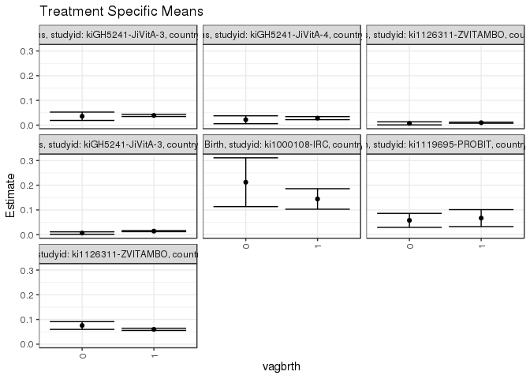

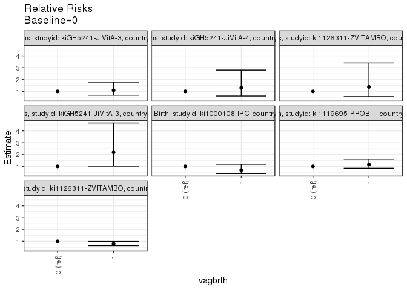

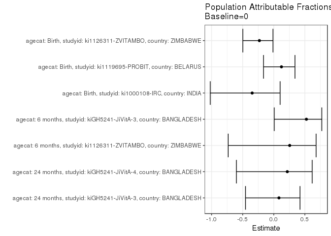

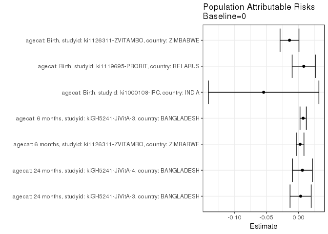

## Results Table

### Parameter: TSM

| agecat | studyid | country | intervention_level | baseline_level | estimate | ci_lower | ci_upper |
| --- | --- | --- | --- | --- | --- | --- | --- |
| Birth | ki1000108-IRC | INDIA | 0 | NA | 0.2121212 | 0.1133497 | 0.3108928 |
| Birth | ki1000108-IRC | INDIA | 1 | NA | 0.1444043 | 0.1029503 | 0.1858583 |
| Birth | ki1119695-PROBIT | BELARUS | 0 | NA | 0.0577527 | 0.0294460 | 0.0860593 |
| Birth | ki1119695-PROBIT | BELARUS | 1 | NA | 0.0669610 | 0.0326677 | 0.1012543 |
| Birth | ki1126311-ZVITAMBO | ZIMBABWE | 0 | NA | 0.0755232 | 0.0599006 | 0.0911458 |
| Birth | ki1126311-ZVITAMBO | ZIMBABWE | 1 | NA | 0.0600137 | 0.0557124 | 0.0643149 |
| 6 months | ki1126311-ZVITAMBO | ZIMBABWE | 0 | NA | 0.0070822 | 0.0008961 | 0.0132682 |
| 6 months | ki1126311-ZVITAMBO | ZIMBABWE | 1 | NA | 0.0097450 | 0.0075203 | 0.0119697 |
| 6 months | kiGH5241-JiVitA-3 | BANGLADESH | 0 | NA | 0.0065116 | 0.0016099 | 0.0114134 |
| 6 months | kiGH5241-JiVitA-3 | BANGLADESH | 1 | NA | 0.0142035 | 0.0120341 | 0.0163728 |
| 24 months | kiGH5241-JiVitA-3 | BANGLADESH | 0 | NA | 0.0357895 | 0.0189031 | 0.0526759 |
| 24 months | kiGH5241-JiVitA-3 | BANGLADESH | 1 | NA | 0.0392327 | 0.0347479 | 0.0437174 |
| 24 months | kiGH5241-JiVitA-4 | BANGLADESH | 0 | NA | 0.0216718 | 0.0056736 | 0.0376701 |
| 24 months | kiGH5241-JiVitA-4 | BANGLADESH | 1 | NA | 0.0282225 | 0.0220464 | 0.0343986 |

### Parameter: E(Y)

| agecat | studyid | country | intervention_level | baseline_level | estimate | ci_lower | ci_upper |
| --- | --- | --- | --- | --- | --- | --- | --- |
| Birth | ki1000108-IRC | INDIA | NA | NA | 0.1574344 | 0.1188345 | 0.1960344 |
| Birth | ki1119695-PROBIT | BELARUS | NA | NA | 0.0658999 | 0.0328405 | 0.0989593 |
| Birth | ki1126311-ZVITAMBO | ZIMBABWE | NA | NA | 0.0613439 | 0.0571889 | 0.0654990 |
| 6 months | ki1126311-ZVITAMBO | ZIMBABWE | NA | NA | 0.0095157 | 0.0074139 | 0.0116175 |
| 6 months | kiGH5241-JiVitA-3 | BANGLADESH | NA | NA | 0.0137085 | 0.0116390 | 0.0157780 |
| 24 months | kiGH5241-JiVitA-3 | BANGLADESH | NA | NA | 0.0390415 | 0.0347089 | 0.0433741 |
| 24 months | kiGH5241-JiVitA-4 | BANGLADESH | NA | NA | 0.0276946 | 0.0218340 | 0.0335552 |

### Parameter: RR

| agecat | studyid | country | intervention_level | baseline_level | estimate | ci_lower | ci_upper |
| --- | --- | --- | --- | --- | --- | --- | --- |
| Birth | ki1000108-IRC | INDIA | 0 | 0 | 1.0000000 | 1.0000000 | 1.0000000 |
| Birth | ki1000108-IRC | INDIA | 1 | 0 | 0.6807633 | 0.3939399 | 1.1764196 |
| Birth | ki1119695-PROBIT | BELARUS | 0 | 0 | 1.0000000 | 1.0000000 | 1.0000000 |
| Birth | ki1119695-PROBIT | BELARUS | 1 | 0 | 1.1594443 | 0.8449585 | 1.5909788 |
| Birth | ki1126311-ZVITAMBO | ZIMBABWE | 0 | 0 | 1.0000000 | 1.0000000 | 1.0000000 |
| Birth | ki1126311-ZVITAMBO | ZIMBABWE | 1 | 0 | 0.7946387 | 0.6383995 | 0.9891152 |
| 6 months | ki1126311-ZVITAMBO | ZIMBABWE | 0 | 0 | 1.0000000 | 1.0000000 | 1.0000000 |
| 6 months | ki1126311-ZVITAMBO | ZIMBABWE | 1 | 0 | 1.3759978 | 0.5578710 | 3.3939209 |
| 6 months | kiGH5241-JiVitA-3 | BANGLADESH | 0 | 0 | 1.0000000 | 1.0000000 | 1.0000000 |
| 6 months | kiGH5241-JiVitA-3 | BANGLADESH | 1 | 0 | 2.1812447 | 1.0194849 | 4.6668944 |
| 24 months | kiGH5241-JiVitA-3 | BANGLADESH | 0 | 0 | 1.0000000 | 1.0000000 | 1.0000000 |
| 24 months | kiGH5241-JiVitA-3 | BANGLADESH | 1 | 0 | 1.0962070 | 0.6740508 | 1.7827587 |
| 24 months | kiGH5241-JiVitA-4 | BANGLADESH | 0 | 0 | 1.0000000 | 1.0000000 | 1.0000000 |
| 24 months | kiGH5241-JiVitA-4 | BANGLADESH | 1 | 0 | 1.3022679 | 0.6065679 | 2.7958972 |

### Parameter: PAR

| agecat | studyid | country | intervention_level | baseline_level | estimate | ci_lower | ci_upper |
| --- | --- | --- | --- | --- | --- | --- | --- |
| Birth | ki1000108-IRC | INDIA | 0 | NA | -0.0546868 | -0.1412394 | 0.0318658 |
| Birth | ki1119695-PROBIT | BELARUS | 0 | NA | 0.0081472 | -0.0100292 | 0.0263236 |
| Birth | ki1126311-ZVITAMBO | ZIMBABWE | 0 | NA | -0.0141793 | -0.0289935 | 0.0006350 |
| 6 months | ki1126311-ZVITAMBO | ZIMBABWE | 0 | NA | 0.0024335 | -0.0035742 | 0.0084412 |
| 6 months | kiGH5241-JiVitA-3 | BANGLADESH | 0 | NA | 0.0071968 | 0.0022767 | 0.0121170 |
| 24 months | kiGH5241-JiVitA-3 | BANGLADESH | 0 | NA | 0.0032520 | -0.0132789 | 0.0197829 |
| 24 months | kiGH5241-JiVitA-4 | BANGLADESH | 0 | NA | 0.0060228 | -0.0095887 | 0.0216342 |

### Parameter: PAF

| agecat | studyid | country | intervention_level | baseline_level | estimate | ci_lower | ci_upper |
| --- | --- | --- | --- | --- | --- | --- | --- |
| Birth | ki1000108-IRC | INDIA | 0 | NA | -0.3473625 | -1.0213073 | 0.1018754 |
| Birth | ki1119695-PROBIT | BELARUS | 0 | NA | 0.1236302 | -0.1649149 | 0.3407038 |
| Birth | ki1126311-ZVITAMBO | ZIMBABWE | 0 | NA | -0.2311435 | -0.4974336 | -0.0122081 |
| 6 months | ki1126311-ZVITAMBO | ZIMBABWE | 0 | NA | 0.2557383 | -0.7325140 | 0.6802765 |
| 6 months | kiGH5241-JiVitA-3 | BANGLADESH | 0 | NA | 0.5249924 | 0.0071734 | 0.7727375 |
| 24 months | kiGH5241-JiVitA-3 | BANGLADESH | 0 | NA | 0.0832966 | -0.4543321 | 0.4221779 |
| 24 months | kiGH5241-JiVitA-4 | BANGLADESH | 0 | NA | 0.2174713 | -0.6006481 | 0.6174355 |